# The Effect of Vitamin C on Tooth Growth in Guinea Pigs

Jonathan Bouchet

November 21, 2015

## *Instruction*

1. Load the ToothGrowth data and perform some basic exploratory data analyses
2. Provide a basic summary of the data.
3. Use confidence intervals and/or hypothesis tests to compare tooth growth by supp and dose. (Only use the techniques from class, even if there’s other approaches worth considering)
4. State your conclusions and the assumptions needed for your conclusions.

## *Preambule*

```r
library(datasets)
data(ToothGrowth)
```

A brief explanation of the data is given in the help :

```r
help(ToothGroth)
```

An overview of the data shows that it consists of a dataframe with 60 observations on 3 variables :

```r
>str(ToothGrowth)
'data.frame':   60 obs. of  3 variables:
 $ len : num  4.2 11.5 7.3 5.8 6.4 10 11.2 11.2 5.2 7 ...
 $ supp: Factor w/ 2 levels "OJ","VC": 2 2 2 2 2 2 2 2 2 2 ...
 $ dose: num  0.5 0.5 0.5 0.5 0.5 0.5 0.5 0.5 0.5 0.5 ...
>summary(ToothGrowth)
      len        supp         dose
 Min.   : 4.20   OJ:30   Min.   :0.500
 1st Qu.:13.07   VC:30   1st Qu.:0.500
 Median :19.25           Median :1.000
 Mean   :18.81           Mean   :1.167
 3rd Qu.:25.27           3rd Qu.:2.000
 Max.   :33.90           Max.   :2.000
```

We can summarize the data with the following plot :

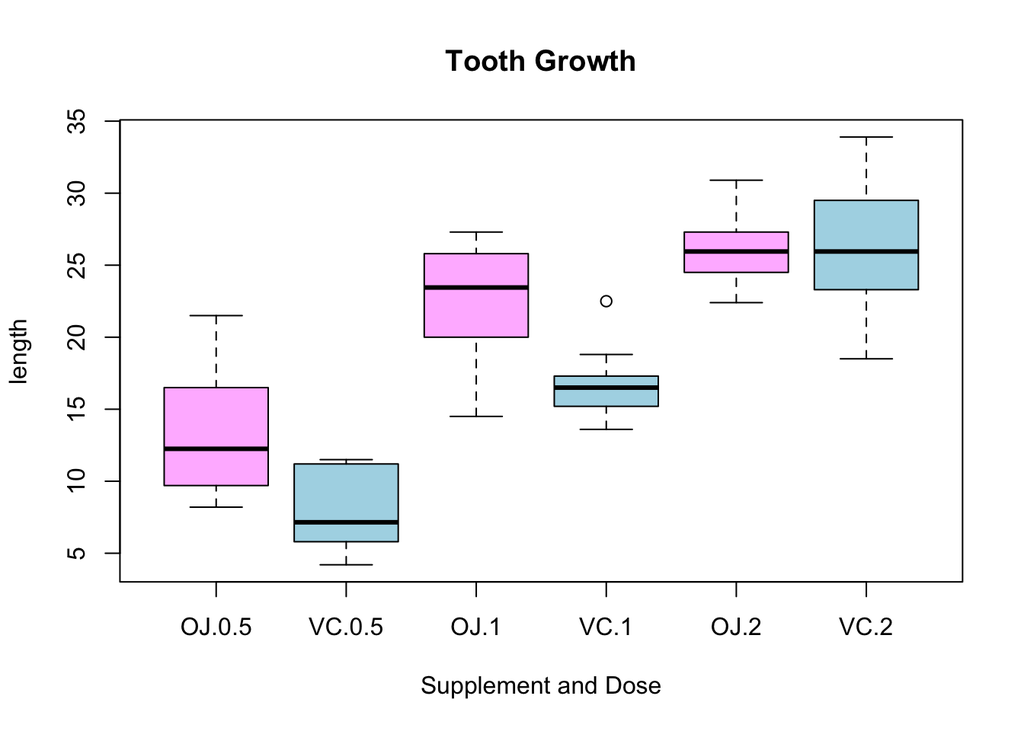

```r
boxplot(len~supp*dose, data=ToothGrowth,col=(c("plum1","lightblue")),main="Tooth Growth", xlab="Supplement and Dose",ylab="length")
```

### *Comments :*

To make the manipulation of the data :

```r
attach(ToothGrowth)
```

## *Analysis*

We split the original dataset into 6 columns (3 doses, 2 supplements) before doing the confidence intervals with t-tests, and we rename them.

```r
DoseGroups<-as.data.frame(split(len,list(supp,dose)))
names(DoseGroups) <- c('OJ_d05','VC_d05','OJ_d1','VC_d1','OJ_d2','VC_d2')
```

```r
> str(DoseGroups)
'data.frame':   10 obs. of  6 variables:
 $ OJ_d05: num  15.2 21.5 17.6 9.7 14.5 10 8.2 9.4 16.5 9.7
 $ VC_d05: num  4.2 11.5 7.3 5.8 6.4 10 11.2 11.2 5.2 7
 $ OJ_d1 : num  19.7 23.3 23.6 26.4 20 25.2 25.8 21.2 14.5 27.3
 $ VC_d1 : num  16.5 16.5 15.2 17.3 22.5 17.3 13.6 14.5 18.8 15.5
 $ OJ_d2 : num  25.5 26.4 22.4 24.5 24.8 30.9 26.4 27.3 29.4 23
 $ VC_d2 : num  23.6 18.5 33.9 25.5 26.4 32.5 26.7 21.5 23.3 29.5
```

As the number of observations are the same for each group, it doesn’t make a difference whether the variances are equal for different groups or not. We do all the analysis assuming unequal variance.

The null hypothesis tested ($H_{0}$) is : there is no difference in the mean for each supplement and therefore $\textbf{OJ}$ and $\textbf{VC}$ have the same effect on tooth growth.

We display the results of the lower (“low”) and upper (“up”) value of the Confidence Interval, as well as the p-value for each dose.

```r
i<-1;
counter<-1;
M<-matrix(ncol=3,nrow=3);
dimnames(M) = list(c("dose=0.5 mg","dose=1.0 mg","dose=2.0 mg"),c("low","up","p-value"));
while ( i < 6) {
  M[counter,1]<-t.test(DoseGroups[i] - DoseGroups[i+1],paired = F,var.equal = F)$conf.int[1];
  M[counter,2]<-t.test(DoseGroups[i] - DoseGroups[i+1],paired = F,var.equal = F)$conf.int[2];
  M[counter,3]<-t.test(DoseGroups[i] - DoseGroups[i+1],paired = F,var.equal = F)$p.value;
  i<-i+2;
  counter<-counter+1;}
print(M)
```

```
##                   low       up     p-value
## dose=0.5 mg  1.263458 9.236542 0.015472048
## dose=1.0 mg  1.951911 9.908089 0.008229248
## dose=2.0 mg -4.328976 4.168976 0.966956704
```

We see that :

1. the confidence levels for dose = 0.5 mg and dose = 1.0 mg do not contain zero, and the p-value is lower than 0.05. In these 2 cases we can reject the $H_{0}$. Thus the difference in the mean we had seen with the plot between the 2 supplements is real.
2. For the last dose, the Confidence interval does contains zero with a p-value>.95, thus we cannot reject the null hypothesis, thus we cannot conclude on the efffectiveness of the impact between the 2 supplements for this dose.

### *notes*

```r
t.test(DoseGroups['OJ_d05'] - DoseGroups['VC_d1'],paired = F,var.equal = F)$conf
```

```
## [1] -6.7059785 -0.3740215
## attr(,"conf.level")
## [1] 0.95
```

```r
t.test(DoseGroups['OJ_d05'] - DoseGroups['VC_d2'],paired = F,var.equal = F)$conf
```

```
## [1] -18.257975  -7.562025
## attr(,"conf.level")
## [1] 0.95
```